# Untitled

KMD

January 17, 2019

# Data Import

Read in data from archive. Alaska Department of Fish and Game, Division of Commercial Fisheries. 2017. Daily salmon escapement counts from the OceanAK database, Alaska, 1921-2017. Knowledge Network for Biocomplexity. https://doi.org/10.5063/F1S46Q6M.

```
##        Location SASAP.Region sampleDate Species DailyCount  Method
## 1 Akalura Creek       Kodiak 1930-05-24 Sockeye          4 Unknown
## 2 Akalura Creek       Kodiak 1930-05-25 Sockeye         10 Unknown
## 3 Akalura Creek       Kodiak 1930-05-26 Sockeye          0 Unknown
## 4 Akalura Creek       Kodiak 1930-05-27 Sockeye          0 Unknown
## 5 Akalura Creek       Kodiak 1930-05-28 Sockeye          0 Unknown
## 6 Akalura Creek       Kodiak 1930-05-29 Sockeye          0 Unknown
##   Latitude Longitude Source
## 1  57.1641 -154.2287   ADFG
## 2  57.1641 -154.2287   ADFG
## 3  57.1641 -154.2287   ADFG
## 4  57.1641 -154.2287   ADFG
## 5  57.1641 -154.2287   ADFG
## 6  57.1641 -154.2287   ADFG
```

# Data Tidying

Calculate annual, regional total escapement.

- `separate` the date into year-month-day
- `group_by` and `summarize` to calculate the sum over unique region-year-species combinations
- `filter` for salmon species only

Creating a dynamic table using the DT package

```r
datatable(annual_esc)
```

|  | SASAP.Region | Species | year | escapement |
| --- | --- | --- | --- | --- |
| 1 | Alaska Peninsula and Aleutian Islands | Chinook | 1974 | 1092 |
| 2 | Alaska Peninsula and Aleutian Islands | Chinook | 1975 | 1917 |
| 3 | Alaska Peninsula and Aleutian Islands | Chinook | 1976 | 3045 |
| 4 | Alaska Peninsula and Aleutian Islands | Chinook | 1977 | 4844 |
| 5 | Alaska Peninsula and Aleutian Islands | Chinook | 1978 | 3901 |
| 6 | Alaska Peninsula and Aleutian Islands | Chinook | 1979 | 10463 |
| 7 | Alaska Peninsula and Aleutian Islands | Chinook | 1980 | 4506 |
| 8 | Alaska Peninsula and Aleutian Islands | Chinook | 1981 | 5046 |
| 9 | Alaska Peninsula and Aleutian Islands | Chinook | 1982 | 6503 |
| 10 | Alaska Peninsula and Aleutian Islands | Chinook | 1983 | 11589 |

[output cut: 1474 more lines]

# Static Plots

Pretty plots in ggplot2

`aes()` is the aesthetic call and maps everything in your plot to a column in your dataset

*To change things like color, do it in your plot-type call (`geom_col()` in this case)

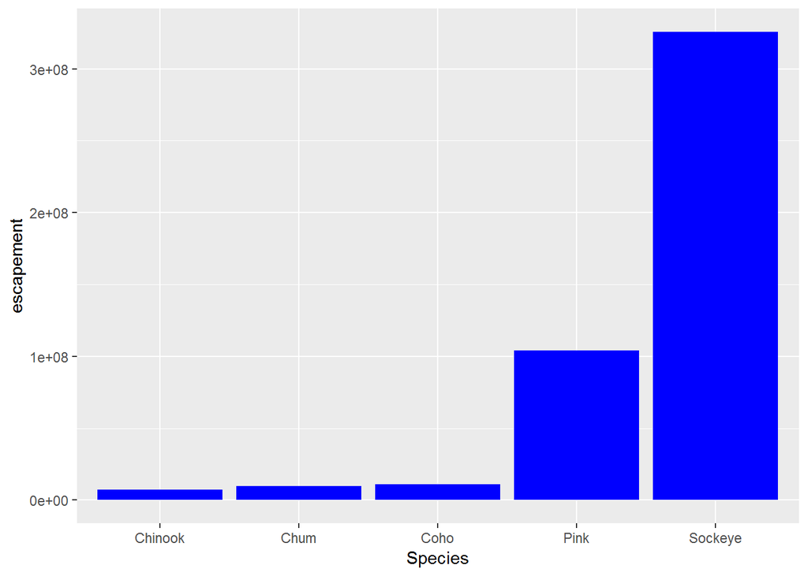

```r
ggplot(data = annual_esc, mapping = aes(x = Species, y = escapement)) +
  geom_col(fill = "blue")
```

But if you want to make colors different based on your data, you CAN put the `fill` in the `aes()` call:

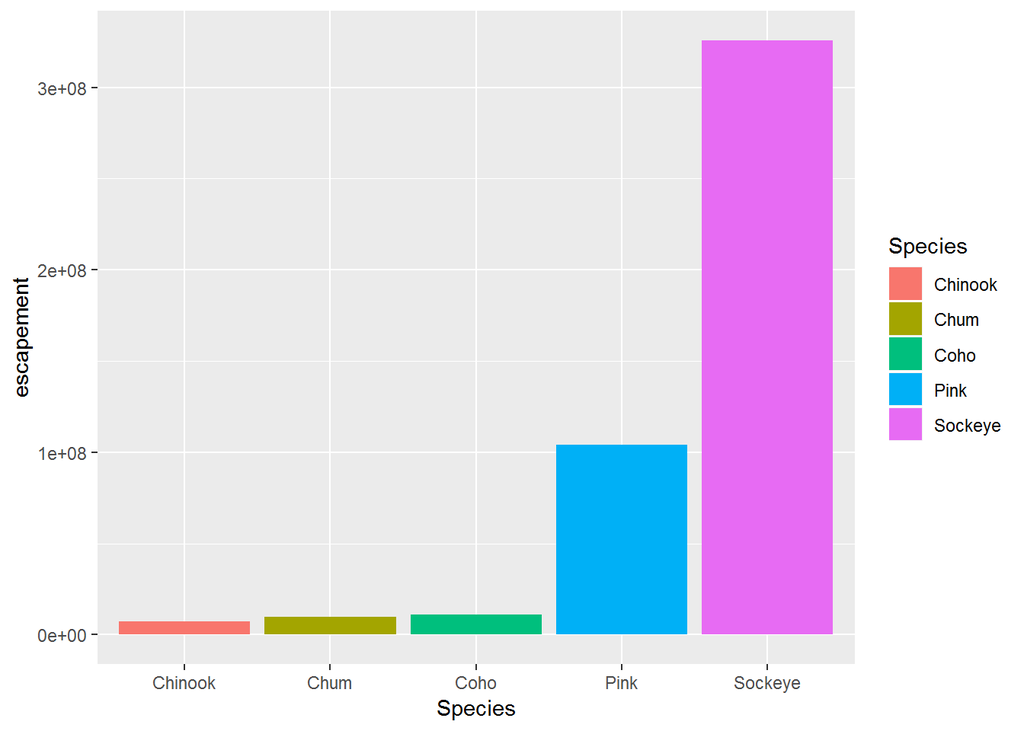

```r
ggplot(data = annual_esc, mapping = aes(x = Species, y = escapement, fill = Species)) +
  geom_col()
```

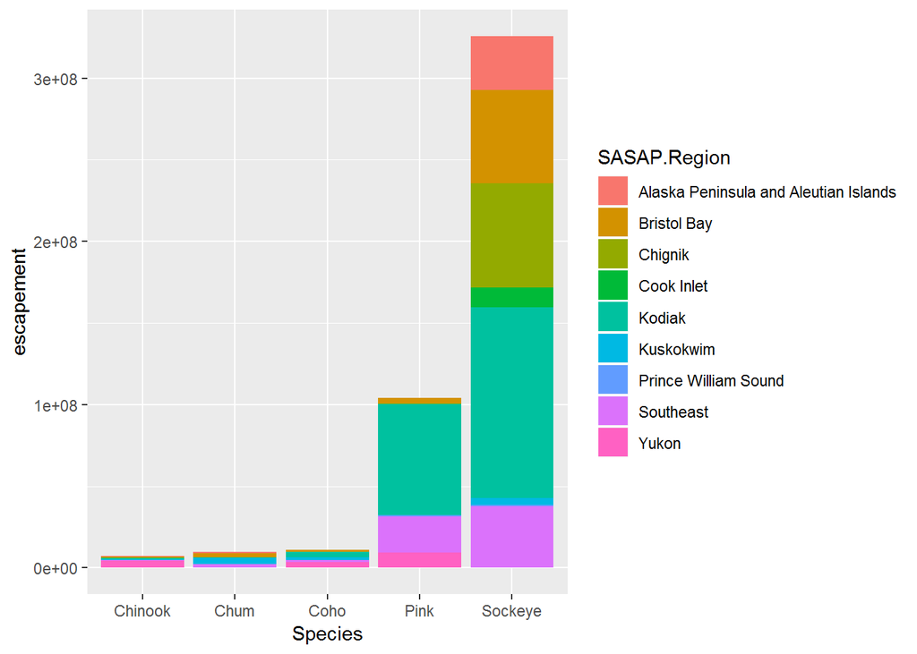

```r
ggplot(data = annual_esc, mapping = aes(x = Species, y = escapement, fill = SASAP.Region)) +
  geom_col()
```

You can also make other neat plots using filters (filtered to JUST the Kodiak data).

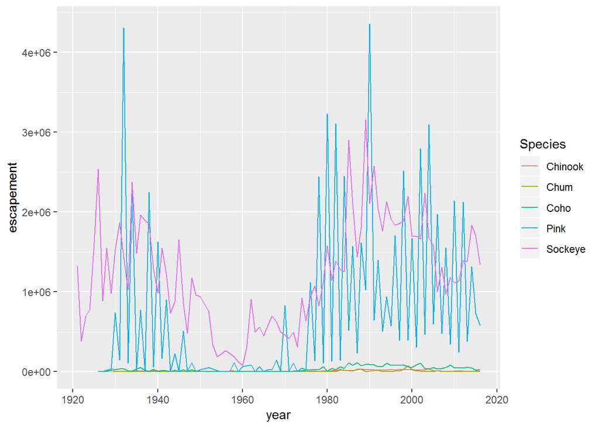

```r
ggplot(data = filter(annual_esc, SASAP.Region == "Kodiak"), aes(x = year, y = escapement, color=Species)) +
  geom_line()
```

We switched to `color` from `fill` because the former is generally used for lines and the latter for shapes.

We can also add multiple geometries to a single plot:

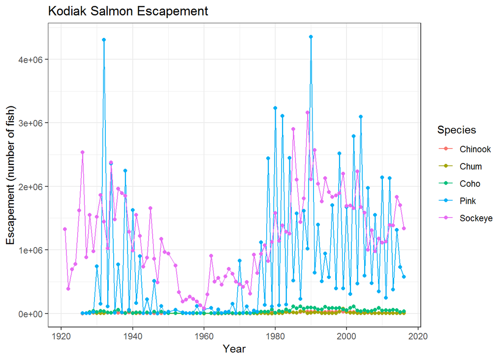

```r
ggplot(data = filter(annual_esc, SASAP.Region == "Kodiak"), aes(x = year, y = escapement, color=Species)) +
  geom_line()+
  geom_point()+
  ylab("Escapement (number of fish)")+
  xlab("Year")+
  ggtitle("Kodiak Salmon Escapement")+
  theme_bw()
```

If you want to keep up with the same sort of plots, then you can set a theme as an object and then can call back to it rather than type it all out again.

## Facet Wrap

Plot timeseries of escapement by species for all regions

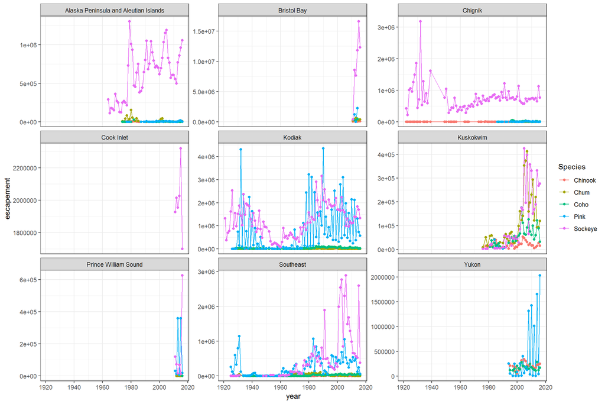

```r
ggplot(annual_esc, aes(x = year, y = escapement, color = Species))+
  geom_line()+
  geom_point()+
  facet_wrap(~SASAP.Region, scales = "free_y")+
  theme_bw()
```

Can also save your plots:

```r
ggsave("region_escapement.png")
```

The default of `ggsave()` is the last printed figure, and not necessarily the one you want to print. To get around, can save the figure as a variable, then plot the variable:

```r
fig <- ggplot(annual_esc, aes(x = year, y = escapement, color = Species))+
  geom_line()+
  geom_point()+
  facet_wrap(~SASAP.Region, scales = "free_y")+
  theme_bw()

ggsave("region_escapement2.png", plot = fig)
```

And then you can also print to a csv file if you have derived data you want to save.

```r
write.csv(annual_esc, "derived_data/annual_esc.csv")
```

Use the ggplot 2 [cheat sheet](https://www.rstudio.com/wp-content/uploads/2015/03/ggplot2-cheatsheet.pdf)!

# Nifty Interactive Maps!

Make a map using leaflet

- find unique locations with lat/long values

```r
locations <- esc %>%
  distinct(Location, Latitude, Longitude) %>%
  drop_na() #must be willing to lose ALL information on ANY row with an NA

datatable(locations)
```

|  | Location | Latitude | Longitude |
| --- | --- | --- | --- |
| 1 | Akalura Creek | 57.1641 | -154.2287 |
| 4 | Anvik River | 62.7 | -160.2 |
| 6 | Ayakulik River | 57.1956 | -154.529 |
| 7 | Bear Creek | 56.0389 | -160.2734 |
| 8 | Bear River | 56.0389 | -160.2734 |
| 9 | Big Bay Creek | 58.5426 | -152.5683 |
| 10 | Big Kitoi Creek | 58.1915 | -152.3754 |
| 12 | Black Lake | 56.392 | -158.937 |
| 13 | Buskin River | 57.7768 | -152.5372 |
| 14 | Chelatna Lake | 62.4731 | -151.4545 |

[output cut: 58 more lines]

Create the interactive map!

```r
leaflet(locations) %>%
  addTiles() %>%  #adds open source background tiles to map
  addMarkers(~ Longitude, ~ Latitude, popup = ~ Location) #adds markers and popups with location names
```

[interactive chart not shown]

So neat!